# EDS 222: Assignment 01

Julia Parish Co-authors: Clarissa Boyajian, Grace Lewin, Juliet Cohen

2021-09-30

*(The case study in this exercise is based on reality, but does not include actual observational data.)*

# Air Pollution in Lahore, Pakistan

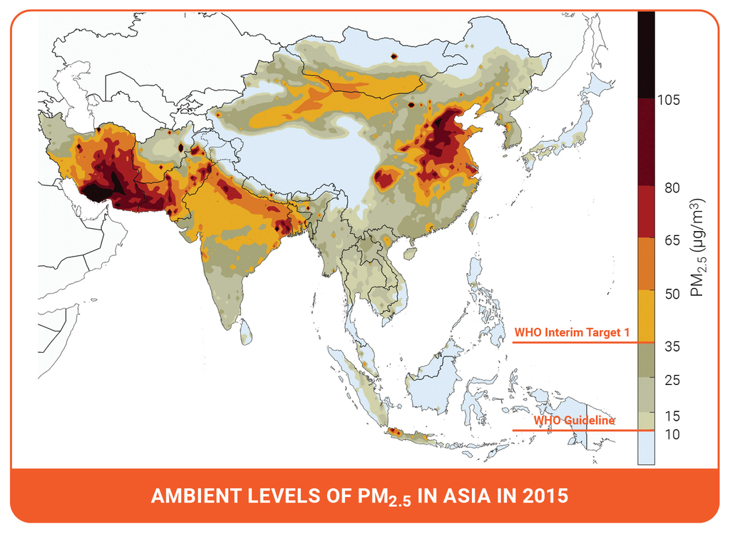

In this exercise we will look at a case study concerning air quality in South Asia. The World Health Organization estimates that air pollution kills an estimated seven million people per year, due to its effects on the cardiovascular and respiratory systems. Out of the 40 most polluted cities in the world, South Asia is home to 37, and Pakistan was ranked to contain the second most air pollution in the world in 2020 (IQAIR, 2020). In 2019, Lahore, Pakistan was the 12th most polluted city in the world, exposing a population of 11.1 million people to increased mortality and morbidity risks.

In this exercise, you are given two datasets from Lahore, Pakistan and are asked to compare the two different data collection strategies from this city. These data are:

All data for EDS 222 will be stored on the Taylor server, in the shared `/courses/EDS222/data/` directory. Please see material from EDS 214 on how to access and retrieve data from Taylor. These data are small; all compute can be handled locally.

- Crowd-sourced data from air quality monitors located in people’s homes. These data are voluntarily collected by individual households who choose to install a monitor in their home and upload their data for public access.
- Official government data from monitors installed by government officials at selected locations across Lahore. There have been reports that government officials strategically locate monitors in locations with cleaner air in order to mitigate domestic and international pressure to clean up the air.

In answering the following questions, please consider the lecture content from class on sampling strategies, as well as the material in Chapter 2 of [*Introduction to Modern Statistics*](https://openintro-ims.netlify.app/). Include in your submission an `.Rmd` file and a compiled `.html` file, each containing complete answers to all questions (as well as all your code in the `.Rmd`).

## Question 1:

Load the data from each source and label it as `crowdsourced` and `govt` accordingly. For example:

```r
crowdsourced <- readRDS(here::here
                      ("Data", "airpol-PK-crowdsourced.RDS"))
govt <- readRDS(here::here ("Data", "airpol-PK-govt.RDS"))
```

```r
crowdsourced_rows <- nrow(crowdsourced)
crowdsourced_rows
```

```
## [1] 5488
```

```r
govt_rows <- nrow(govt)
govt_rows
```

```
## [1] 1960
```

1. These dataframes have one row per pollution observation. How many pollution records are in each dataset?
- In the dataset `crowdsourced` there are 5488 pollution records.
- In the dataset `govt` there are 1960 pollution records.
2. Each monitor is located at a unique latitude and longitude location. How many unique monitors are in each dataset?

```r
govt_monitors <- govt %>%
  group_by(longitude, latitude) %>%
  summarize() %>%
  rowid_to_column("ID")

crowdsourced_monitors <- crowdsourced %>%
  group_by(longitude, latitude) %>%
  summarize() %>%
  rowid_to_column("ID")
```

- The `crowdsourced` dataset has 14 unique monitors.
- The `govt` dataset has 5 unique monitors.

## Question 2:

The goal of pollution monitoring in Lahore is to measure the average pollution conditions across the city.

1. What is the *population* in this setting? Please be precise.
- The *population* in this pollution monitoring research is the air in Lahore, Pakistan.
2. What are the *samples* in this setting? Please be precise.
- There are two *sample* datasets: `crowdsourced` and `govt`. The `crowdsourced` sample data was collected in community members’ homes. The `govt` sample data was collected in selected locations in Lahore by government officials.
3. These samples were not randomly collected from across locations in Lahore. Given the sampling approaches described above, discuss possible biases that may enter when we use these samples to construct estimates of population parameters.
- There are a number of potential selectional biases with either dataset. The `crowdsourced` data is a *convenience sample* resulting in undercoverage within the Lahore population. Monitors are located in homes where the individuals volunteered to have the units installed and were willing and able to upload the data as well as share the data publicly. These factors may lead to *nonresponse* or *voluntary response biases*. Community members may also be concerned about retribution from governmental officials or businesses if the data collected in their homes contradicts official data results. The official governmental data, `govt`, is influenced by *undercoverage* and *site-selection biases*. There is no reference to how monitoring sites were selected. The Lahore government would benefit economically and politically if monitoring sites were located in areas with reduced PM levels.

## Question 3:

```r
govt_summary <- summary(govt$PM)

govt_mean <- round(mean(govt$PM), 2)
govt_min <- round(min(govt$PM), 2)
govt_max <- round(max(govt$PM), 2)

govt_mean
```

```
## [1] 39.65
```

```r
crowdsourced_summary <- summary(crowdsourced$PM)

cs_mean <- round(mean(crowdsourced$PM), 2)
cs_min <- round(min(crowdsourced$PM), 2)
cs_max <- round(max(crowdsourced$PM), 2)

cs_mean
```

```
## [1] 70.2
```

1. For both the government data and the crowd-sourced data, report the sample mean, sample minimum, and sample maximum value of PM 2.5 (measured in $\mu g/m^3$).
- The government collected PM 2.5 data has a sample mean of 39.65 $\mu g/m^3$, a sample minimum 15 $\mu g/m^3$, and a sample maximum of 65 $\mu g/m^3$.
- The crowdsourced PM 2.5 data has a sample mean of 70.2 $\mu g/m^3$, a sample minimum 20 $\mu g/m^3$, and a sample maximum of 120 $\mu g/m^3$.
2. Discuss any key differences that you see between these two samples.
- The data collected by the government has lower PM 2.5 measurements than the crowdsourced data.
3. Are the differences in mean pollution as expected, given what we know about the sampling strategies?
- The mean pollution measurement differences are expected due to the potential data biases that have been identified. There is speculation that the government data is skewed to collect data in areas with better air quality. The mean differences infer that this may be a real issue with the government data.

## Question 4:

Use the location of the air pollution stations for both of the sampling strategies to generate a map showing locations of each observation. Color the two samples with different colors to highlight how each sample obtains measurements from different parts of the city.

**Hint:** `longitude` indicates location in the *x*-direction, while `latitude` indicates location in the *y*-direction. With `ggplot2` this should be nothing fancy. We’ll do more spatial data in `R` later in the course.

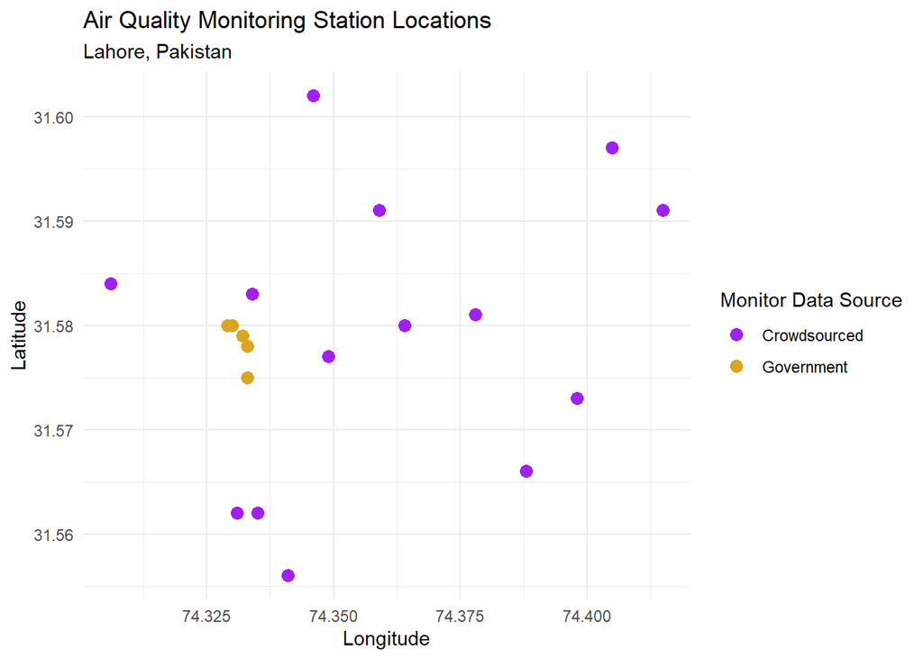

```r
crowdsourced_monitors <- crowdsourced_monitors %>%
  mutate(datasource = "Crowdsourced") # add datasource column to delineate monitor data origin

govt_monitors <- govt_monitors %>%
  mutate(datasource = "Government") # add datasource column to delineate monitor data origin

combined_monitors <- bind_rows(crowdsourced_monitors, govt_monitors) %>% select(-ID) # remove ID column to eliminate duplicate IDs

# Create map of air quality monitor locations
station_plot <- ggplot(data = combined_monitors,
                       aes(x = longitude, y = latitude)) +
                geom_point(aes(color = datasource), size = 3) +
                scale_color_manual(name = "Monitor Data Source", values = c("Crowdsourced" = "purple", "Government" = "goldenrod")) +
                labs(title = "Air Quality Monitoring Station Locations",
                     subtitle = "Lahore, Pakistan",
                     x = "Longitude",
                     y = "Latitude") +
                theme_minimal()

station_plot
```

## Question 5:

The local newspaper in Pakistan, *Dawn*, claims that the government is misreporting the air pollution levels in Lahore. Do the locations of monitors in question 4, relative to crowd-sourced monitors, suggest anything about a possible political bias?/

- When the monitors are plotted, it clearly displays that the government monitors are clustered closely together. The air quality data these monitors collect are not representative of the air quality throughout the city and surrounding urban area. They are clustered around the city’s main railway station and within 3 km of the town hall and city government offices. This does indicate a possible political bias. The government air quality monitors are also conviently located near government official’s offices.

## Question 6:

Given the recent corruption in air quality reporting, the Prime Minister of Pakistan has hired an independent body of environmental data scientists to create an unbiased estimate of the mean PM 2.5 across Lahore using some combination of both government stations and crowd sourced observations.

NASA’s satellite data indicates that the average PM across Lahore is 89.2 $\mu g/m^3$. Since this is the most objective estimate of population-level PM 2.5 available, your goal is to match this mean as closely as possible by creating a new ground-level monitoring sample that draws on both the government and crowd-sourced samples.

### Question 6.1:

First, generate a *random sample* of size $n=1000$ air pollution records by (i) pooling observations across the government and the crowd-sourced data; and (ii) drawing observations at random from this pooled sample.

**Hint:** `bind_rows()` may be helpful.

Second, create a *stratified random sample*. Do so by (i) stratifying your pooled dataset into strata of 0.01 degrees of latitude, and (ii) randomly sampling 200 air pollution observations from each stratum.

```r
crowdsourced <- crowdsourced %>%
  mutate(datasource = "Crowdsourced") # add datasource column to delineate monitor data origin

govt <- govt  %>%
  mutate(datasource = "Government") # add datasource column to delineate monitor data origin

combined_obs <- bind_rows(govt, crowdsourced)

class(combined_obs)
```

```
## [1] "tbl_df"     "tbl"        "data.frame"
```

```r
sample_obvs <- sample(x = combined_obs$PM, size = 1000)
sample_obvs
```

[output not shown]

[output cut: 41 more lines]

```r
strat_random_sample <- combined_obs %>%
  mutate(latitude_round = round(latitude, 2)) %>%
  group_by(latitude_round)

strat_random_sample
```

```
## # A tibble: 7,448 x 6
## # Groups:   latitude_round [5]
##    date          PM latitude longitude datasource latitude_round
##    <date>     <dbl>    <dbl>     <dbl> <chr>               <dbl>
##  1 2018-11-04    28     31.6      74.3 Government           31.6
##  2 2018-11-05    34     31.6      74.3 Government           31.6
##  3 2018-11-06    44     31.6      74.3 Government           31.6
##  4 2018-11-07    60     31.6      74.3 Government           31.6
##  5 2018-11-08    25     31.6      74.3 Government           31.6
##  6 2018-11-09    60     31.6      74.3 Government           31.6
##  7 2018-11-10    62     31.6      74.3 Government           31.6
##  8 2018-11-11    48     31.6      74.3 Government           31.6
##  9 2018-11-12    46     31.6      74.3 Government           31.6
## 10 2018-11-13    25     31.6      74.3 Government           31.6
## # ... with 7,438 more rows
```

### Question 6.2:

Compare estimated means of PM 2.5 for each sampling strategy to the NASA estimate of 89.2 $\mu g/m^3$. Which sample seems to match the satellite data best? What would you recommend the Prime Minister do? Does your proposed sampling strategy rely more on government or on crowd-sourced data? Why might that be the case?

```r
sample_obvs_mean <- round(mean(sample_obvs), 2)
sample_obvs_mean
```

```
## [1] 62.28
```

```r
sr_sample_mean <- round(mean(strat_random_sample$PM), 2)
sr_sample_mean
```

```
## [1] 62.16
```